# project2a

Shaya Engelman

2023-10-13

```r
library(tidyverse)
library(RCurl)
```

For this analysis, I chose a dataset posted by Marley Myrianthopoulos in the Slack channel. It is a breakdown of home runs hit by position and team in MLB’s AL East division over the last five full seasons (2020 had a shortened season due to the pandemic). The question I want answered is if the HRs by the Catcher position have decreased over time. As a casual baseball fan, my feeling has been over the last few years teams have prioritized the defense at the catching position more than the offense and I would expect to see a decrease over time at catcher.

```r
homers <- read.csv("https://raw.githubusercontent.com/Shayaeng/Data607/main/Project2/baseball_hr.csv")
```

First I will filter out the other positions and lengthen the table to have the year as a value.

```r
homers_long <- homers %>%
  pivot_longer(
    cols = starts_with("X"),
    names_to = "Year",
    values_to = "Total_HRs"
  ) %>%
  mutate(Year = as.numeric(str_extract(Year, "\\d+"))) %>%
  filter(!is.na(Total_HRs) & Position == "C")
```

Now I will plot the data to see if there was a trend over the last few years.

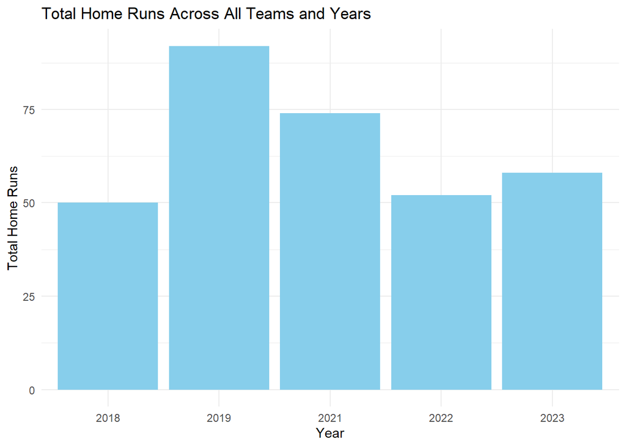

```r
ggplot(homers_long, aes(x = factor(Year), y = Total_HRs)) +
  geom_bar(stat = "identity", fill = "skyblue") +
  labs(title = "Total Home Runs Across All Teams and Years",
       x = "Year",
       y = "Total Home Runs") +
  theme_minimal()
```

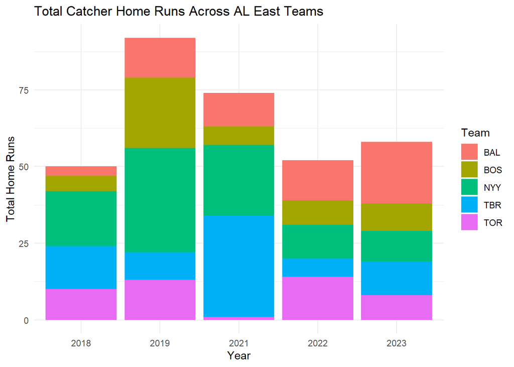

```r
ggplot(homers_long, aes(x = factor(Year), y = Total_HRs, fill = Team)) +
  geom_bar(stat = "identity") +
  labs(title = "Total Catcher Home Runs Across AL East Teams",
       x = "Year",
       y = "Total Home Runs") +
  theme_minimal()
```

The first plot does seem to show an overall downward trend (albeit over a very small sample size) starting in 2019. However, by recreating the plot with a team by team breakdown there seems to have been one specific team in both 2019 and 2021 with oversize production from their catchers, NYY and TBR. A quick Google search will turn up that they were both voted as All Stars in those specific season and thus cannot be indicative of league-wide trends.

In conclusion, I would say my hypothesis was wrong and there does not seem to be a trend of lower catcher totals. However, this is not a very large sample size and there is evidence for the theory so it is not enough data to draw conclusions.